# Modelos Lineales en R con el dataset MPG

ICD

# 1 Introducción

En esta clase analizaremos el dataset **`mpg`**, disponible en `tidyverse`.

```r
help(mpg)
mpg
```

```
## # A tibble: 234 × 11
##    manufacturer model      displ  year   cyl trans drv     cty   hwy fl    class
##    <chr>        <chr>      <dbl> <int> <int> <chr> <chr> <int> <int> <chr> <chr>
##  1 audi         a4           1.8  1999     4 auto… f        18    29 p     comp…
##  2 audi         a4           1.8  1999     4 manu… f        21    29 p     comp…
##  3 audi         a4           2    2008     4 manu… f        20    31 p     comp…
##  4 audi         a4           2    2008     4 auto… f        21    30 p     comp…
##  5 audi         a4           2.8  1999     6 auto… f        16    26 p     comp…
##  6 audi         a4           2.8  1999     6 manu… f        18    26 p     comp…
##  7 audi         a4           3.1  2008     6 auto… f        18    27 p     comp…
##  8 audi         a4 quattro   1.8  1999     4 manu… 4        18    26 p     comp…
##  9 audi         a4 quattro   1.8  1999     4 auto… 4        16    25 p     comp…
## 10 audi         a4 quattro   2    2008     4 manu… 4        20    28 p     comp…
## # ℹ 224 more rows
```

Vamos a estudiar la relación entre el **rendimiento en ruta** (`hwy`, “Highway miles per gallon”) y la **cilindrada del motor** (`displ`).

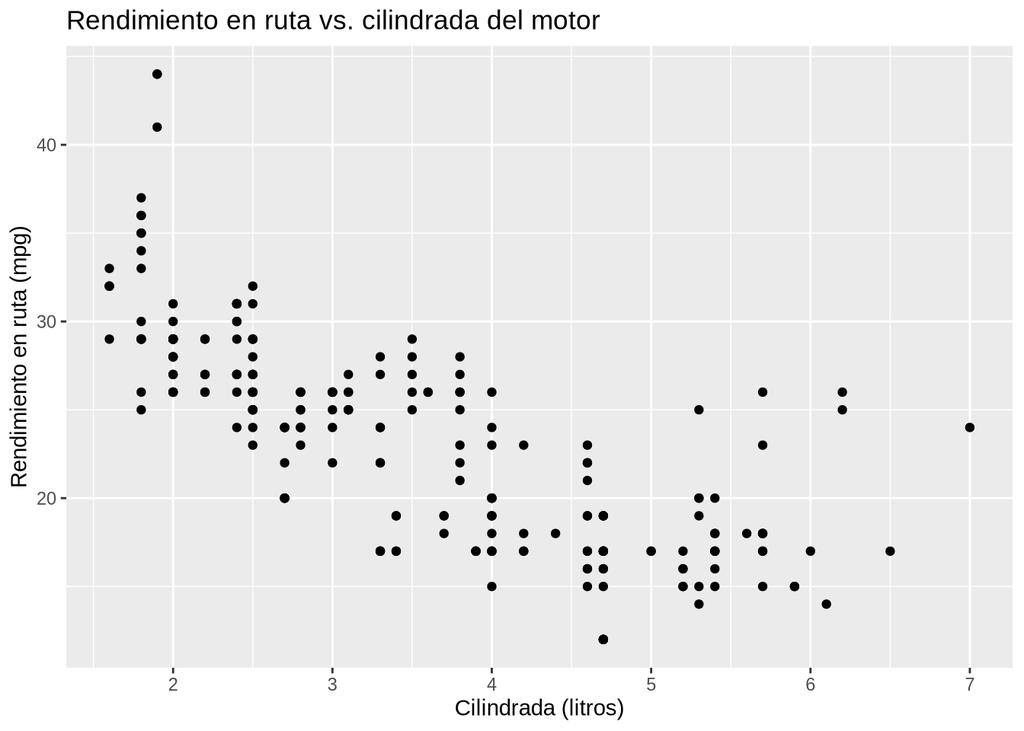

```r
ggplot(data = mpg) +
  geom_point(aes(x = displ, y = hwy)) +
  labs(title = "Rendimiento en ruta vs. cilindrada del motor",
       x = "Cilindrada (litros)", y = "Rendimiento en ruta (mpg)")
```

Guardemos este gráfico para reutilizarlo más adelante:

```r
p <- ggplot(data = mpg) +
  geom_point(aes(x = displ, y = hwy)) +
  labs(x = "Cilindrada (displ)", y = "Rendimiento (hwy)")
```

# 2 Mod: Modelado lineal simple

Queremos modelar la relación suponiendo una **relación lineal** entre `displ` y `hwy`:

$$hwy = w_0 + w_1 \times displ$$

Creamos el modelo y analizamos su resumen. Fíjense la relación entre la notación/sintaxis de R y la ecuación matemática.

R modela, es decir, busca parámetros de la ecuación tal que se ajuste a los datos observados. En este caso de modelo lineal simple, hay una ordenada al origen y una pendiente.

```r
mod <- lm(hwy ~ displ, data = mpg)
summary(mod)
```

```
##
## Call:
## lm(formula = hwy ~ displ, data = mpg)
##
## Residuals:
##     Min      1Q  Median      3Q     Max
## -7.1039 -2.1646 -0.2242  2.0589 15.0105
##
## Coefficients:
##             Estimate Std. Error t value Pr(>|t|)
## (Intercept)  35.6977     0.7204   49.55   <2e-16 ***
## displ        -3.5306     0.1945  -18.15   <2e-16 ***
## ---
## Signif. codes:  0 '***' 0.001 '**' 0.01 '*' 0.05 '.' 0.1 ' ' 1
##
## Residual standard error: 3.836 on 232 degrees of freedom
## Multiple R-squared:  0.5868, Adjusted R-squared:  0.585
## F-statistic: 329.5 on 1 and 232 DF,  p-value: < 2.2e-16
```

**Preguntas para reflexionar:**

- ¿Qué opinan de la significancia? ¿Parece que hay relación?
- ¿Cómo interpretamos los parámetros?

Algunos puntos importantes:

- **Residual standard error:** una forma de medir la dispersión de los residuos.
  - 3.836 on 232 degrees of freedom: la predicción se desvia +- 3.8
- **R² ajustado:** proporción de variabilidad total de hwy explicada por el modelo.
  - Multiple R-squared: 0.5868, Adjusted R-squared: 0.585
    - casi un 59% de la variabilidad en los datos de hwy se puede atribuir a la cilindrada)
    - ver para detalles (https://www.datacamp.com/es/tutorial/adjusted-r-squared)
- **F-statistic:** compara el modelo actual contra uno sin predictores.
  - F-statistic: 329.5 on 1 and 232 DF, p-value: < 2.2e-16  
    Mide si la mejora es estadisticamente significativa contra el modelo que sólo tiene el intercepto (valores más grandes es “mejor”, p chico es “mejor”)

## 2.1 Grilla de predicciones

Si vemos los valores de displ, notamos que sólo aparecen algunos valores. Entonces, vamos a usar una grilla de las variables (en este caso displ) en lugar del dataset entero (35 vs 234)

```r
length(unique(mpg$displ))
```

```
## [1] 35
```

```r
grilla <- data_grid(mpg, displ) %>%
  add_predictions(model = mod)

grilla
```

```
## # A tibble: 35 × 2
##    displ  pred
##    <dbl> <dbl>
##  1   1.6  30.0
##  2   1.8  29.3
##  3   1.9  29.0
##  4   2    28.6
##  5   2.2  27.9
##  6   2.4  27.2
##  7   2.5  26.9
##  8   2.7  26.2
##  9   2.8  25.8
## 10   3    25.1
## # ℹ 25 more rows
```

Visualizamos el modelo junto con los datos:

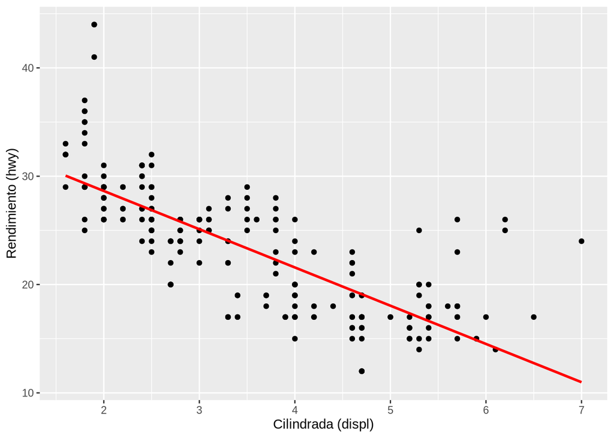

```r
p + geom_line(data = grilla, aes(x = displ, y = pred), color = "red", size = 1)
```

- Extrapolando: ¿qué les parece que pasa si miramos para cilindradas <0? ¿Y para valores >>>7?

## 2.2 Análisis de residuos

Los residuos son la diferencia entre el valor observado y el predicho.

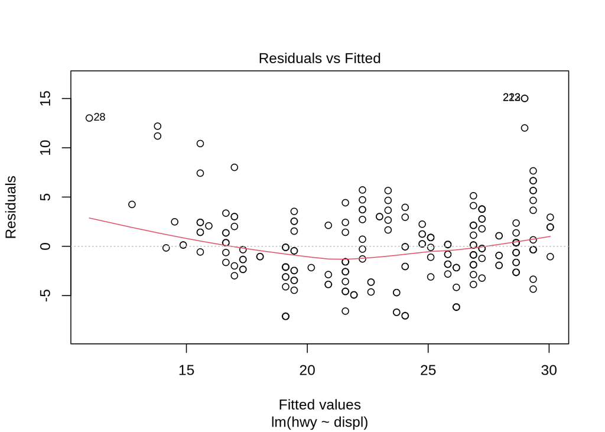

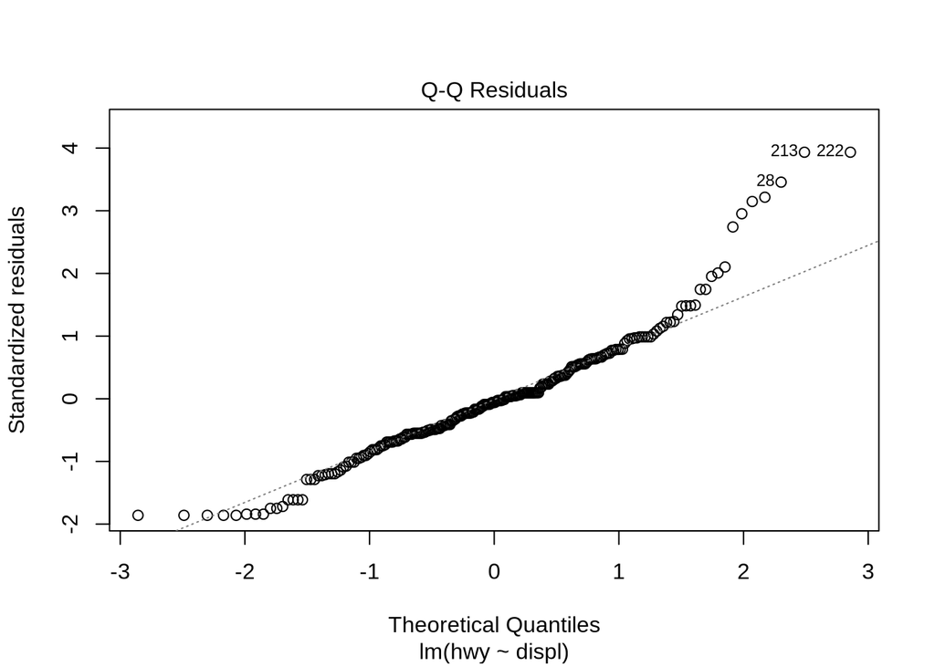

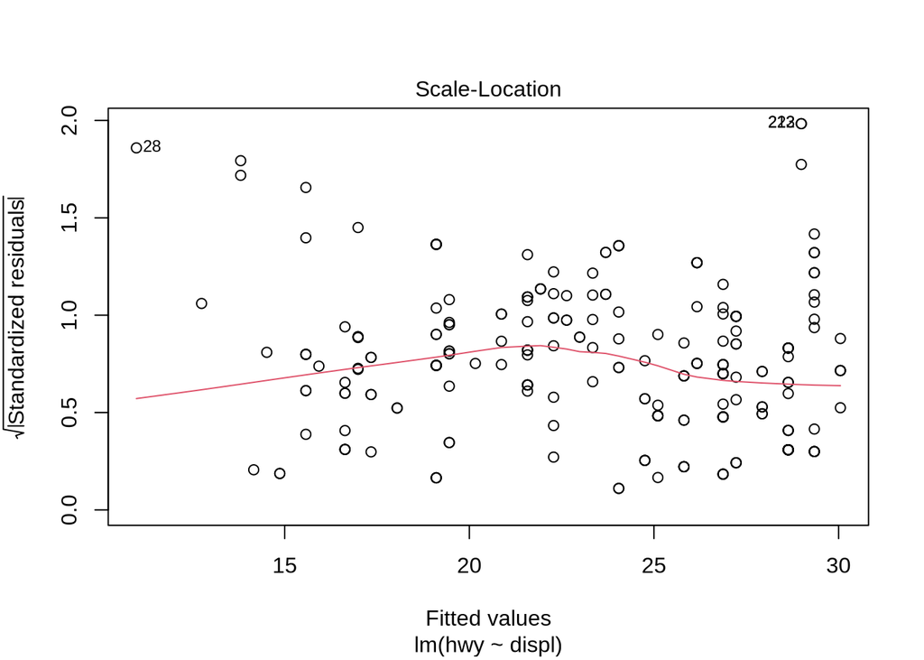

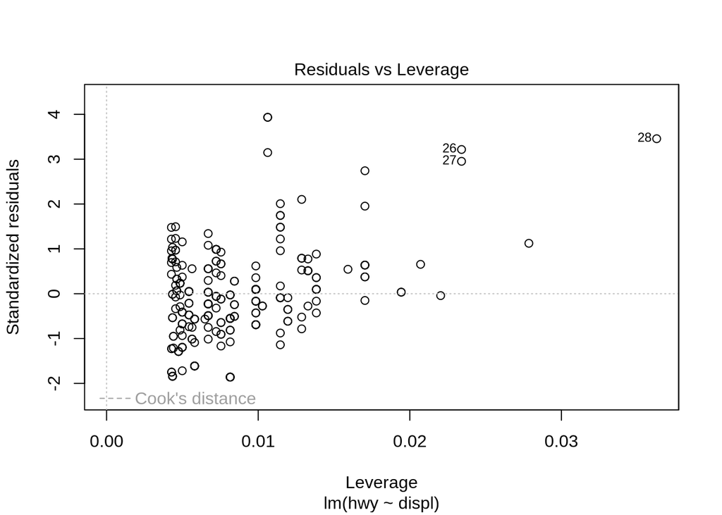

```r
plot(mod)
```

Podemos obtenerlos manualmente, con el código de abajo. Comparemos el dataset original, cuando sumamos los residuos, y cómo cambia respecto de la grilla de antes.

```r
mpg1 <- mpg %>%
  add_predictions(model = mod) %>%
  add_residuals(model = mod, var = "resid") %>% relocate(displ, pred, resid)

mpg  %>% relocate(displ)
```

```
## # A tibble: 234 × 11
##    displ manufacturer model       year   cyl trans drv     cty   hwy fl    class
##    <dbl> <chr>        <chr>      <int> <int> <chr> <chr> <int> <int> <chr> <chr>
##  1   1.8 audi         a4          1999     4 auto… f        18    29 p     comp…
##  2   1.8 audi         a4          1999     4 manu… f        21    29 p     comp…
##  3   2   audi         a4          2008     4 manu… f        20    31 p     comp…
##  4   2   audi         a4          2008     4 auto… f        21    30 p     comp…
##  5   2.8 audi         a4          1999     6 auto… f        16    26 p     comp…
##  6   2.8 audi         a4          1999     6 manu… f        18    26 p     comp…
##  7   3.1 audi         a4          2008     6 auto… f        18    27 p     comp…
##  8   1.8 audi         a4 quattro  1999     4 manu… 4        18    26 p     comp…
##  9   1.8 audi         a4 quattro  1999     4 auto… 4        16    25 p     comp…
## 10   2   audi         a4 quattro  2008     4 manu… 4        20    28 p     comp…
## # ℹ 224 more rows
```

```r
mpg1
```

```
## # A tibble: 234 × 13
##    displ  pred  resid manufacturer model      year   cyl trans drv     cty   hwy
##    <dbl> <dbl>  <dbl> <chr>        <chr>     <int> <int> <chr> <chr> <int> <int>
##  1   1.8  29.3 -0.343 audi         a4         1999     4 auto… f        18    29
##  2   1.8  29.3 -0.343 audi         a4         1999     4 manu… f        21    29
##  3   2    28.6  2.36  audi         a4         2008     4 manu… f        20    31
##  4   2    28.6  1.36  audi         a4         2008     4 auto… f        21    30
##  5   2.8  25.8  0.188 audi         a4         1999     6 auto… f        16    26
##  6   2.8  25.8  0.188 audi         a4         1999     6 manu… f        18    26
##  7   3.1  24.8  2.25  audi         a4         2008     6 auto… f        18    27
##  8   1.8  29.3 -3.34  audi         a4 quatt…  1999     4 manu… 4        18    26
##  9   1.8  29.3 -4.34  audi         a4 quatt…  1999     4 auto… 4        16    25
## 10   2    28.6 -0.636 audi         a4 quatt…  2008     4 manu… 4        20    28
## # ℹ 224 more rows
## # ℹ 2 more variables: fl <chr>, class <chr>
```

```r
grilla
```

```
## # A tibble: 35 × 2
##    displ  pred
##    <dbl> <dbl>
##  1   1.6  30.0
##  2   1.8  29.3
##  3   1.9  29.0
##  4   2    28.6
##  5   2.2  27.9
##  6   2.4  27.2
##  7   2.5  26.9
##  8   2.7  26.2
##  9   2.8  25.8
## 10   3    25.1
## # ℹ 25 more rows
```

### 2.2.1 Residuos vs predicción:

No siempre vamos a poder graficar los datos, pero siempre vamos a poder graficar y analizar los residuos.

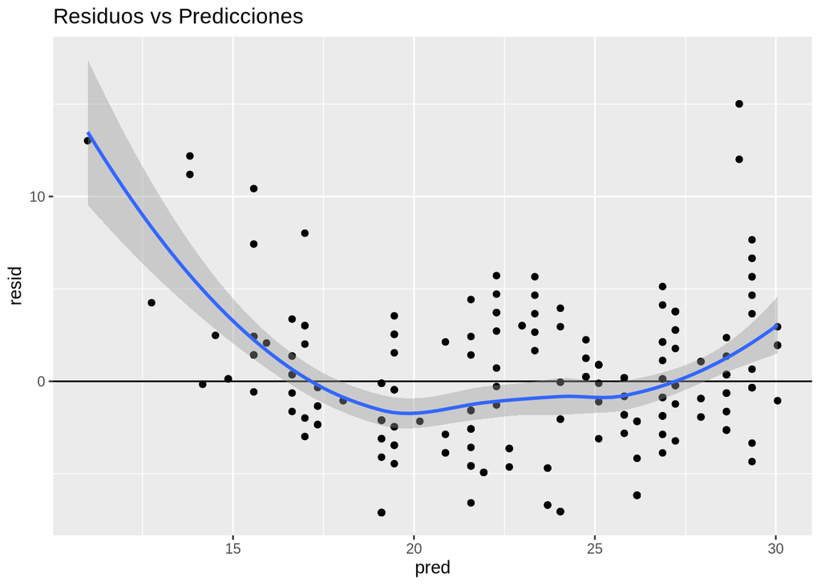

```r
ggplot(mpg1, aes(x = pred, y = resid)) +
  geom_point() +
  geom_hline(yintercept = 0) +
  geom_smooth() +
  labs(title = "Residuos vs Predicciones")
```

### 2.2.2 Residuos vs variable predictora:

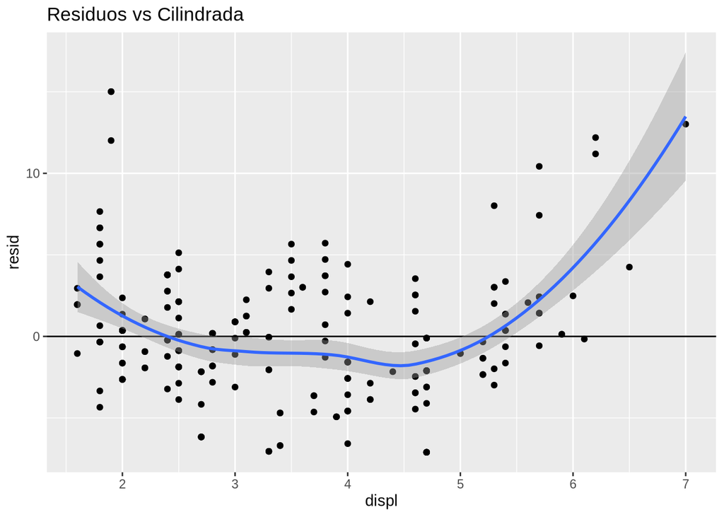

```r
ggplot(mpg1, aes(x = displ, y = resid)) +
  geom_point() +
  geom_hline(yintercept = 0) +
  geom_smooth() +
  labs(title = "Residuos vs Cilindrada")
```

# 3 Mod2: Modelo cuadrático

Probemos con una forma más flexible: vamos a tratar de mejorar el modelo incorporando funciones no lineales de la variable predictora.

¿Qué piensan que va a pasar con el número de parámetros si utilizamos, por ejemplo, una relación cuadrática con el volumen del motor?

$$hwy = w_0 + w_1 \times displ + w_2 \times displ^2$$

```r
mod2 <- lm(hwy ~ displ + I(displ^2), data = mpg)  #observar cómo tenemos que usar I y no poner * directamente!
summary(mod2)
```

```
##
## Call:
## lm(formula = hwy ~ displ + I(displ^2), data = mpg)
##
## Residuals:
##     Min      1Q  Median      3Q     Max
## -6.6258 -2.1700 -0.7099  2.1768 13.1449
##
## Coefficients:
##             Estimate Std. Error t value Pr(>|t|)
## (Intercept)  49.2450     1.8576  26.510  < 2e-16 ***
## displ       -11.7602     1.0729 -10.961  < 2e-16 ***
## I(displ^2)    1.0954     0.1409   7.773 2.51e-13 ***
## ---
## Signif. codes:  0 '***' 0.001 '**' 0.01 '*' 0.05 '.' 0.1 ' ' 1
##
## Residual standard error: 3.423 on 231 degrees of freedom
## Multiple R-squared:  0.6725, Adjusted R-squared:  0.6696
## F-statistic: 237.1 on 2 and 231 DF,  p-value: < 2.2e-16
```

La I es para decirle que no interprete nada, simplemente que ponga literalmente el displ al cuadrado.

- ¿Cuantos coeficientes tiene el modelo ahora? ¿podemos interpretar tan facilmente como antes?
- ¿Cómo se comparan las métricas con los valores del modelo simple?

```r
summary(mod)
```

```
##
## Call:
## lm(formula = hwy ~ displ, data = mpg)
##
## Residuals:
##     Min      1Q  Median      3Q     Max
## -7.1039 -2.1646 -0.2242  2.0589 15.0105
##
## Coefficients:
##             Estimate Std. Error t value Pr(>|t|)
## (Intercept)  35.6977     0.7204   49.55   <2e-16 ***
## displ        -3.5306     0.1945  -18.15   <2e-16 ***
## ---
## Signif. codes:  0 '***' 0.001 '**' 0.01 '*' 0.05 '.' 0.1 ' ' 1
##
## Residual standard error: 3.836 on 232 degrees of freedom
## Multiple R-squared:  0.5868, Adjusted R-squared:  0.585
## F-statistic: 329.5 on 1 and 232 DF,  p-value: < 2.2e-16
```

Alternativamente, y muy útil si se quieren usar grados más altos, está “poly”. Ojo que para comparar directamente con la notación I hay que aclarar raw = TRUE.

```r
mod2_1 <- lm(hwy ~ poly(displ, 2, raw = TRUE), data = mpg)
summary(mod2_1)
```

```
##
## Call:
## lm(formula = hwy ~ poly(displ, 2, raw = TRUE), data = mpg)
##
## Residuals:
##     Min      1Q  Median      3Q     Max
## -6.6258 -2.1700 -0.7099  2.1768 13.1449
##
## Coefficients:
##                             Estimate Std. Error t value Pr(>|t|)
## (Intercept)                  49.2450     1.8576  26.510  < 2e-16 ***
## poly(displ, 2, raw = TRUE)1 -11.7602     1.0729 -10.961  < 2e-16 ***
## poly(displ, 2, raw = TRUE)2   1.0954     0.1409   7.773 2.51e-13 ***
## ---
## Signif. codes:  0 '***' 0.001 '**' 0.01 '*' 0.05 '.' 0.1 ' ' 1
##
## Residual standard error: 3.423 on 231 degrees of freedom
## Multiple R-squared:  0.6725, Adjusted R-squared:  0.6696
## F-statistic: 237.1 on 2 and 231 DF,  p-value: < 2.2e-16
```

Visualizamos:

```r
grilla2 <- data_grid(mpg, displ) %>%
  add_predictions(model = mod2)

grilla
```

```
## # A tibble: 35 × 2
##    displ  pred
##    <dbl> <dbl>
##  1   1.6  30.0
##  2   1.8  29.3
##  3   1.9  29.0
##  4   2    28.6
##  5   2.2  27.9
##  6   2.4  27.2
##  7   2.5  26.9
##  8   2.7  26.2
##  9   2.8  25.8
## 10   3    25.1
## # ℹ 25 more rows
```

```r
grilla2
```

```
## # A tibble: 35 × 2
##    displ  pred
##    <dbl> <dbl>
##  1   1.6  33.2
##  2   1.8  31.6
##  3   1.9  30.9
##  4   2    30.1
##  5   2.2  28.7
##  6   2.4  27.3
##  7   2.5  26.7
##  8   2.7  25.5
##  9   2.8  24.9
## 10   3    23.8
## # ℹ 25 more rows
```

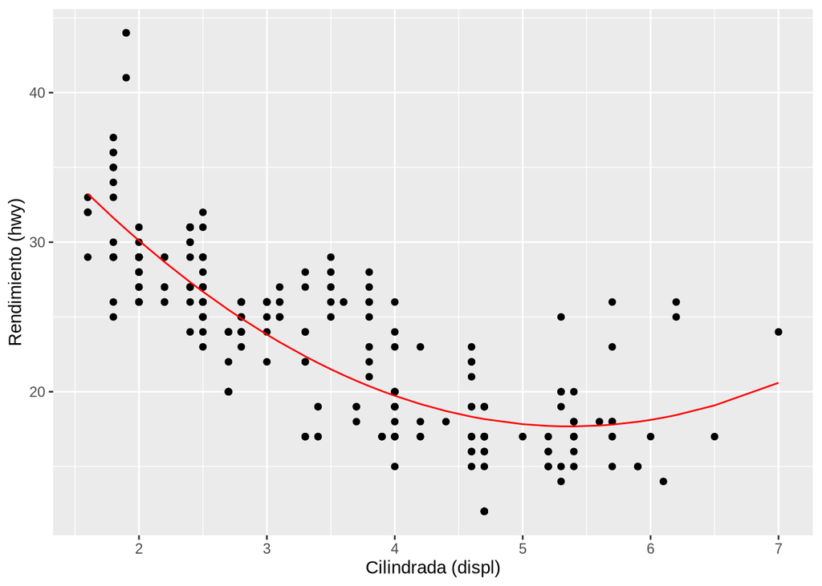

```r
p + geom_line(data = grilla2, aes(x = displ, y = pred), color = "red")
```

Parece que la recta “sigue” mejor a los datos, veamos los residuos:

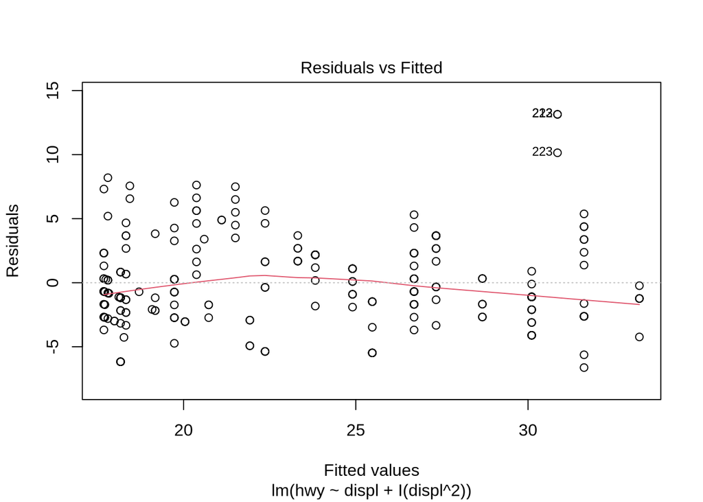

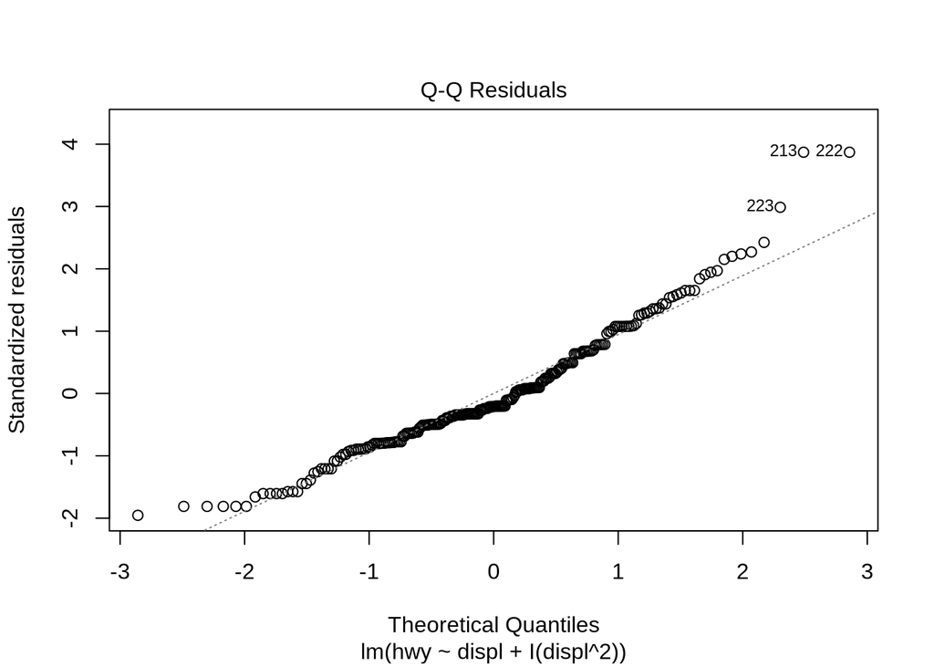

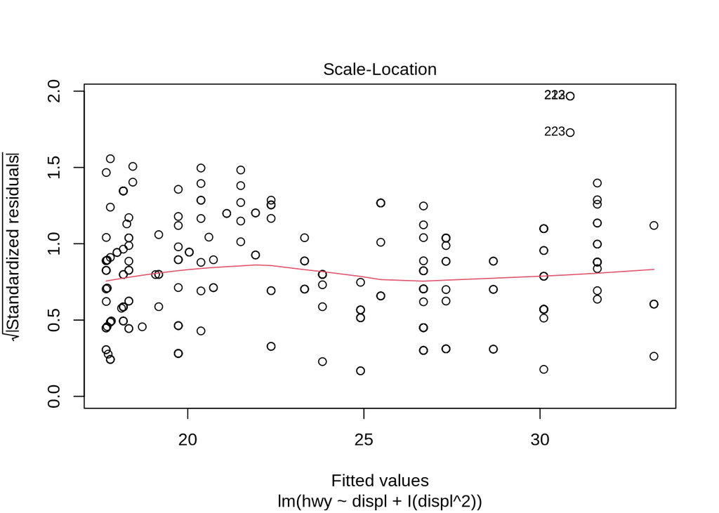

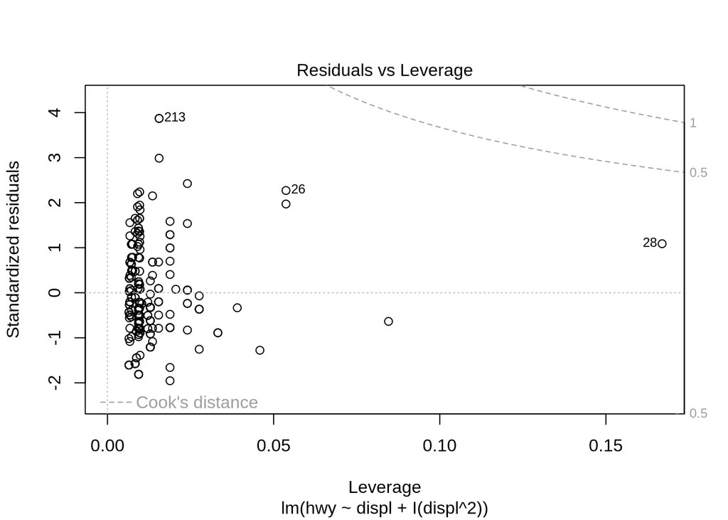

```r
plot(mod2)
```

Nota: como acá estamos usando la misma variable, pero agregando otro grado, podríamos haber usado la misma grilla de antes, y sumado las predicciones de este modelo.

```r
grilla2_2 <- grilla %>% add_predictions(model = mod2, var = "pred2")

grilla
```

```
## # A tibble: 35 × 2
##    displ  pred
##    <dbl> <dbl>
##  1   1.6  30.0
##  2   1.8  29.3
##  3   1.9  29.0
##  4   2    28.6
##  5   2.2  27.9
##  6   2.4  27.2
##  7   2.5  26.9
##  8   2.7  26.2
##  9   2.8  25.8
## 10   3    25.1
## # ℹ 25 more rows
```

```r
grilla2_2
```

```
## # A tibble: 35 × 3
##    displ  pred pred2
##    <dbl> <dbl> <dbl>
##  1   1.6  30.0  33.2
##  2   1.8  29.3  31.6
##  3   1.9  29.0  30.9
##  4   2    28.6  30.1
##  5   2.2  27.9  28.7
##  6   2.4  27.2  27.3
##  7   2.5  26.9  26.7
##  8   2.7  26.2  25.5
##  9   2.8  25.8  24.9
## 10   3    25.1  23.8
## # ℹ 25 more rows
```

# 4 Mod3: Agregando una segunda variable continua

Sigamos complejizando: ¿el año impactará en el rendimiento del auto? Sumemos esta segunda variable “continua”.

$$hwy = w_0 + w_1 \times displ + w_2 \times year$$

```r
mod3 <- lm(hwy ~ displ + year, data = mpg)
summary(mod3)
```

```
##
## Call:
## lm(formula = hwy ~ displ + year, data = mpg)
##
## Residuals:
##     Min      1Q  Median      3Q     Max
## -7.7616 -2.5187 -0.2899  1.8701 15.5852
##
## Coefficients:
##               Estimate Std. Error t value Pr(>|t|)
## (Intercept) -276.15441  111.15444  -2.484  0.01369 *
## displ         -3.61099    0.19383 -18.630  < 2e-16 ***
## year           0.15579    0.05553   2.806  0.00545 **
## ---
## Signif. codes:  0 '***' 0.001 '**' 0.01 '*' 0.05 '.' 0.1 ' ' 1
##
## Residual standard error: 3.78 on 231 degrees of freedom
## Multiple R-squared:  0.6004, Adjusted R-squared:  0.5969
## F-statistic: 173.5 on 2 and 231 DF,  p-value: < 2.2e-16
```

Veamos las preddicciones y el gráfico con el siguiente código. Pensemos:

- ¿cómo cambiará la grilla?
- ¿cómo debe verse el gráfico?

```r
grilla3 <- data_grid(mpg, displ, year) %>%
  add_predictions(model = mod3)

grilla3
```

```
## # A tibble: 70 × 3
##    displ  year  pred
##    <dbl> <int> <dbl>
##  1   1.6  1999  29.5
##  2   1.6  2008  30.9
##  3   1.8  1999  28.8
##  4   1.8  2008  30.2
##  5   1.9  1999  28.4
##  6   1.9  2008  29.8
##  7   2    1999  28.1
##  8   2    2008  29.5
##  9   2.2  1999  27.3
## 10   2.2  2008  28.7
## # ℹ 60 more rows
```

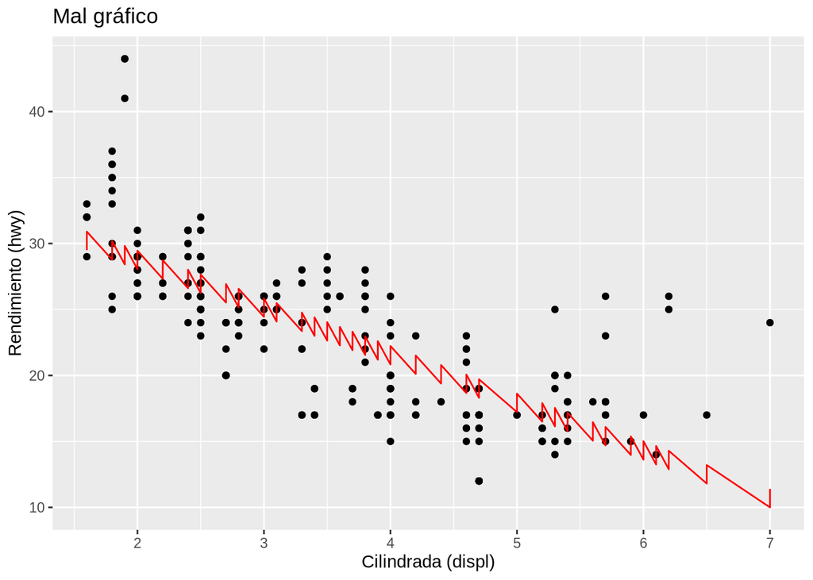

```r
p + geom_line(data=grilla3, aes(x=displ, y=pred), color='red') + labs(title= "Mal gráfico")
```

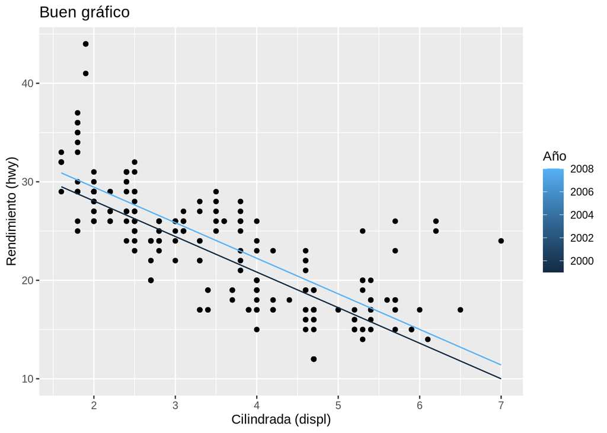

```r
p + geom_line(data = grilla3, aes(x = displ, y = pred, group = year, color = year)) +
  labs(color = "Año", title = "Buen gráfico")
```

```r
unique(mpg$year)
```

```
## [1] 1999 2008
```

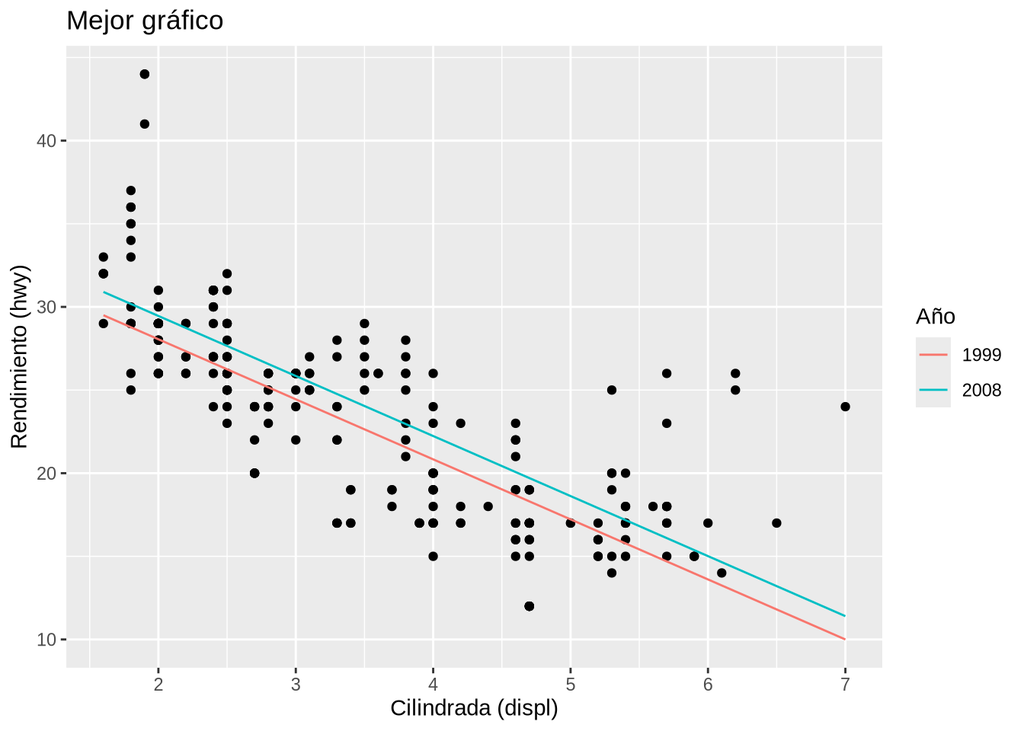

```r
p + geom_line(data=grilla3, aes(x=displ, y=pred, group=year, color=factor(year)))+
  labs(color = "Año", title ="Mejor gráfico")
```

# 5 Mod4: 2 vars - Incorporando una variable categórica

¿Influye el tipo de auto?

```r
unique(mpg$class)
```

```
## [1] "compact"    "midsize"    "suv"        "2seater"    "minivan"
## [6] "pickup"     "subcompact"
```

Modelo con `class`:

```r
mod4 <- lm(hwy ~ displ + class, data = mpg)
summary(mod4)
```

```
##
## Call:
## lm(formula = hwy ~ displ + class, data = mpg)
##
## Residuals:
##    Min     1Q Median     3Q    Max
## -5.572 -1.569 -0.245  1.355 14.724
##
## Coefficients:
##                 Estimate Std. Error t value Pr(>|t|)
## (Intercept)      38.9533     1.7976  21.669  < 2e-16 ***
## displ            -2.2976     0.2132 -10.778  < 2e-16 ***
## classcompact     -5.3122     1.5283  -3.476 0.000610 ***
## classmidsize     -4.9471     1.4722  -3.360 0.000914 ***
## classminivan     -8.7986     1.5939  -5.520 9.26e-08 ***
## classpickup     -11.9232     1.3687  -8.711 6.46e-16 ***
## classsubcompact  -4.6988     1.5097  -3.112 0.002095 **
## classsuv        -10.5851     1.3268  -7.978 7.43e-14 ***
## ---
## Signif. codes:  0 '***' 0.001 '**' 0.01 '*' 0.05 '.' 0.1 ' ' 1
##
## Residual standard error: 2.745 on 226 degrees of freedom
## Multiple R-squared:  0.7939, Adjusted R-squared:  0.7875
## F-statistic: 124.3 on 7 and 226 DF,  p-value: < 2.2e-16
```

Vamos en detalle. R toma el uno los tipos de autos como referencia, (en este caso va ser 2seater”), y va a expresar el intercepto de las otras clases como offsets/correcciones a esta. Conceptualmente seria algo como esto:

2 seater
$$hwy = w_0 + w_1 \times
displ$$

compact
$$hwy = (w_0 +w_c) + w_1 \times
displ$$
midsize
$$hwy = (w_0 +w_m) +
w_1 \times displ$$

Es decir, la pendiente es la misma, cambia la ordenada al origen según cada tipo de auto.

- ¿Cuántos parámetros tiene que tener?

Una pendiente + tantas ordenadas al origen como clases (valores de la categórica: la base + las otras corregidas)

Este coeficiente de “displ” es distinto al que veníamos viendo. Entonces, ¿cómo afecta el volumen del motor del auto al rendimiento del mismo?  
Nuestra respuesta va a depender de la información que tenemos. Si no sabemos el tipo, tenemos que usar el primer modelo donde el valor estimado es promediando la información de todos los autos de manera indistinta. Sería como marginalizando sobre la variable clase, porque no la sabemos.  
Si contamos con la clase de auto, usamos este último modelo, condicionamos a la infomación presente.

Visualizamos:

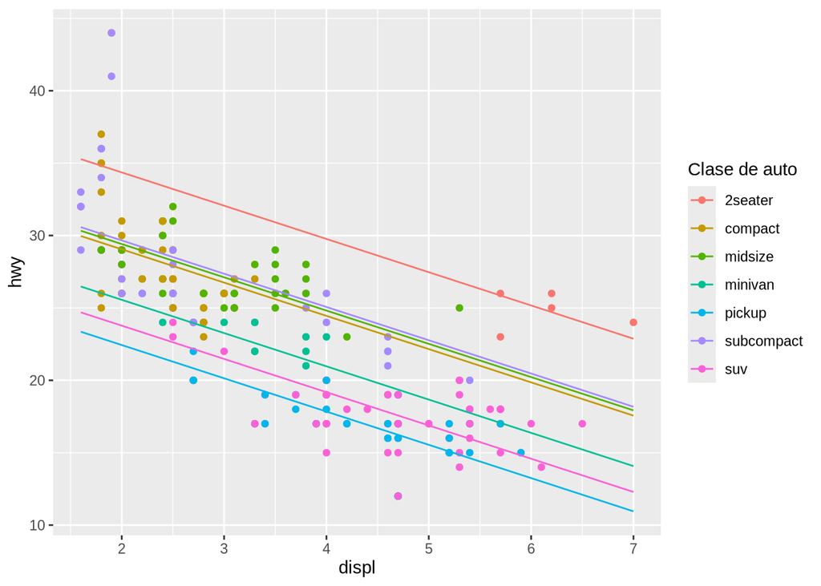

```r
grilla4 <- data_grid(mpg, displ, class) %>%
  add_predictions(model = mod4)

ggplot(mpg) +
  geom_point(aes(x = displ, y = hwy, color = class)) +
  geom_line(data = grilla4, aes(x = displ, y = pred, color = class)) +
  labs(color = "Clase de auto")
```

# 6 Mod5: Modelo polinomial + categórica

```r
mod5 <- lm(hwy ~ poly(displ, 2, raw = TRUE) + class, data = mpg)
summary(mod5)
```

```
##
## Call:
## lm(formula = hwy ~ poly(displ, 2, raw = TRUE) + class, data = mpg)
##
## Residuals:
##     Min      1Q  Median      3Q     Max
## -5.5892 -1.5892 -0.1607  1.2826 13.9018
##
## Coefficients:
##                             Estimate Std. Error t value Pr(>|t|)
## (Intercept)                  44.5544     1.9836  22.462  < 2e-16 ***
## poly(displ, 2, raw = TRUE)1  -7.4345     0.9674  -7.685 4.68e-13 ***
## poly(displ, 2, raw = TRUE)2   0.6822     0.1257   5.429 1.47e-07 ***
## classcompact                 -2.7936     1.5131  -1.846  0.06617 .
## classmidsize                 -1.7069     1.5103  -1.130  0.25961
## classminivan                 -4.9527     1.6608  -2.982  0.00318 **
## classpickup                  -8.6003     1.4277  -6.024 6.89e-09 ***
## classsubcompact              -2.2686     1.4915  -1.521  0.12966
## classsuv                     -7.6055     1.3656  -5.569 7.26e-08 ***
## ---
## Signif. codes:  0 '***' 0.001 '**' 0.01 '*' 0.05 '.' 0.1 ' ' 1
##
## Residual standard error: 2.587 on 225 degrees of freedom
## Multiple R-squared:  0.8177, Adjusted R-squared:  0.8113
## F-statistic: 126.2 on 8 and 225 DF,  p-value: < 2.2e-16
```

- ¿Qué está pasando ahora con la significancia de los coeficientes?

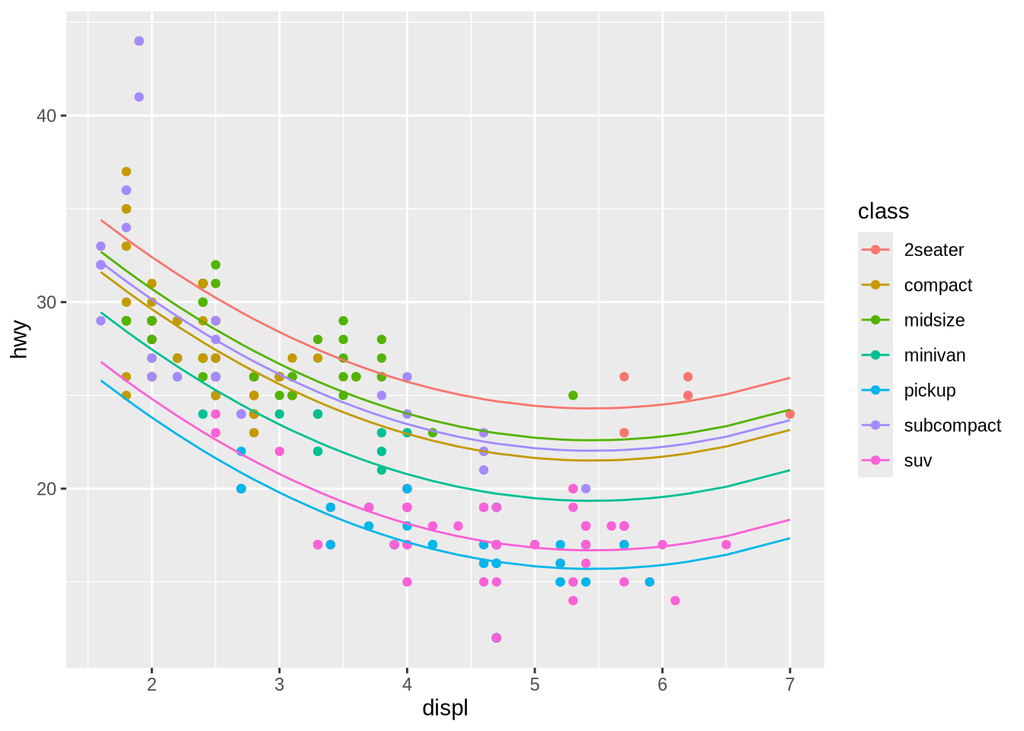

```r
grilla5 <- data_grid(mpg, displ, class) %>%
  add_predictions(model = mod5)

ggplot(mpg) +
  geom_point(aes(x = displ, y = hwy, color = class)) +
  geom_line(data = grilla5, aes(x = displ, y = pred, color = class))
```

Para R, las rectas de 2 seater, compact, midsize y subcompact no son significativamente distinguibles entre sí.

# 7 Mod6: Modelo con múltiples variables

```r
mod6 <- lm(hwy ~ poly(displ, 2, raw = TRUE) + year + class, data = mpg)
summary(mod6)
```

```
##
## Call:
## lm(formula = hwy ~ poly(displ, 2, raw = TRUE) + year + class,
##     data = mpg)
##
## Residuals:
##     Min      1Q  Median      3Q     Max
## -6.1592 -1.3065  0.0332  1.0272 14.3896
##
## Coefficients:
##                               Estimate Std. Error t value Pr(>|t|)
## (Intercept)                 -221.45594   74.42933  -2.975 0.003247 **
## poly(displ, 2, raw = TRUE)1   -7.70190    0.94595  -8.142 2.70e-14 ***
## poly(displ, 2, raw = TRUE)2    0.70257    0.12264   5.729 3.24e-08 ***
## year                           0.13315    0.03724   3.575 0.000429 ***
## classcompact                  -2.99853    1.47611  -2.031 0.043398 *
## classmidsize                  -1.87505    1.47304  -1.273 0.204370
## classminivan                  -4.98009    1.61898  -3.076 0.002359 **
## classpickup                   -8.59850    1.39177  -6.178 3.03e-09 ***
## classsubcompact               -2.42479    1.45456  -1.667 0.096907 .
## classsuv                      -7.63010    1.33120  -5.732 3.19e-08 ***
## ---
## Signif. codes:  0 '***' 0.001 '**' 0.01 '*' 0.05 '.' 0.1 ' ' 1
##
## Residual standard error: 2.522 on 224 degrees of freedom
## Multiple R-squared:  0.8276, Adjusted R-squared:  0.8206
## F-statistic: 119.5 on 9 and 224 DF,  p-value: < 2.2e-16
```

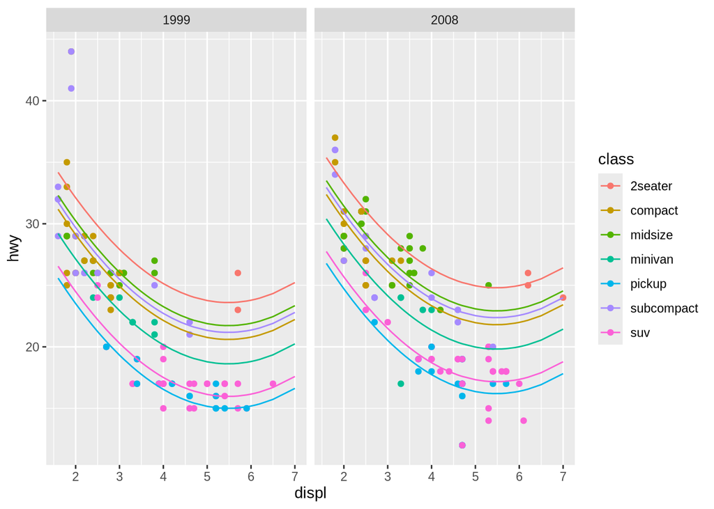

```r
grilla6 <- data_grid(mpg, displ, class, year) %>%
  add_predictions(model = mod6)

ggplot(mpg) +
  geom_point(aes(x = displ, y = hwy, color = class)) +
  geom_line(data = grilla6, aes(x = displ, y = pred, color = class)) +
  facet_wrap(~year)
```

# 8 Mod7: Modelo con dos continuas y dos categóricas

```r
mod7 <- lm(hwy ~ poly(displ, 2, raw = TRUE) + year + class + trans, data = mpg)
summary(mod7)
```

```
##
## Call:
## lm(formula = hwy ~ poly(displ, 2, raw = TRUE) + year + class +
##     trans, data = mpg)
##
## Residuals:
##     Min      1Q  Median      3Q     Max
## -6.2461 -1.2361  0.0265  1.0423 14.0220
##
## Coefficients:
##                               Estimate Std. Error t value Pr(>|t|)
## (Intercept)                 -311.65163   95.54583  -3.262 0.001287 **
## poly(displ, 2, raw = TRUE)1   -7.68092    0.95984  -8.002 7.53e-14 ***
## poly(displ, 2, raw = TRUE)2    0.70310    0.12412   5.664 4.70e-08 ***
## year                           0.17859    0.04763   3.749 0.000228 ***
## classcompact                  -3.70121    1.52224  -2.431 0.015859 *
## classmidsize                  -2.48452    1.52099  -1.633 0.103830
## classminivan                  -5.90152    1.73304  -3.405 0.000789 ***
## classpickup                   -9.23556    1.43748  -6.425 8.36e-10 ***
## classsubcompact               -3.23173    1.50413  -2.149 0.032786 *
## classsuv                      -8.41595    1.40886  -5.974 9.51e-09 ***
## transauto(l3)                 -0.58690    2.23360  -0.263 0.792988
## transauto(l4)                 -0.12364    1.24917  -0.099 0.921247
## transauto(l5)                 -0.68084    1.24231  -0.548 0.584233
## transauto(l6)                  0.84408    1.60340   0.526 0.599129
## transauto(s4)                 -1.14106    1.84771  -0.618 0.537524
## transauto(s5)                  1.32406    1.86108   0.711 0.477580
## transauto(s6)                 -0.98699    1.29619  -0.761 0.447219
## transmanual(m5)                0.38050    1.24791   0.305 0.760729
## transmanual(m6)               -1.36804    1.30252  -1.050 0.294759
## ---
## Signif. codes:  0 '***' 0.001 '**' 0.01 '*' 0.05 '.' 0.1 ' ' 1
##
## Residual standard error: 2.514 on 215 degrees of freedom
## Multiple R-squared:  0.8355, Adjusted R-squared:  0.8218
## F-statistic: 60.68 on 18 and 215 DF,  p-value: < 2.2e-16
```

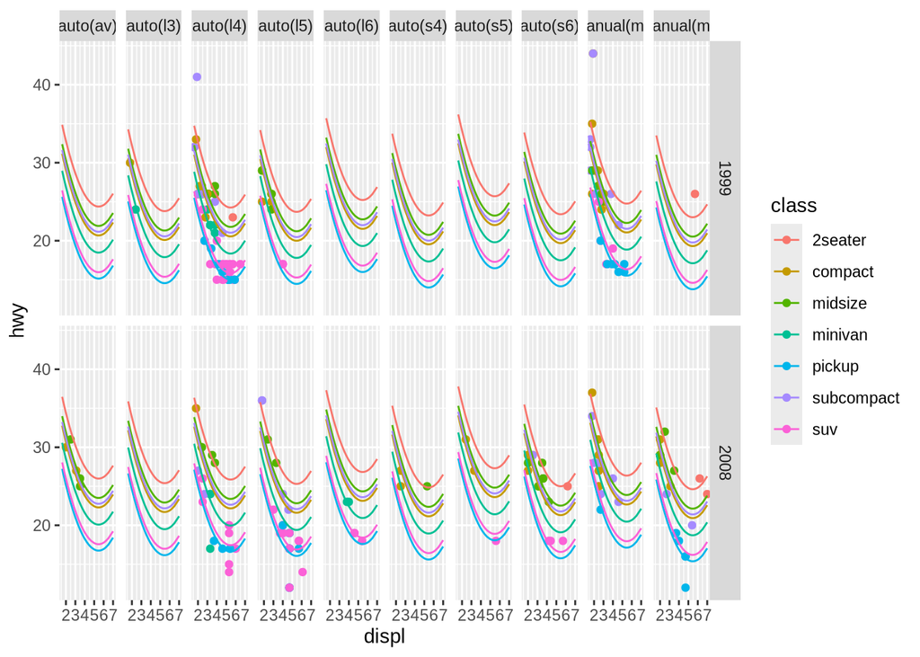

```r
grilla7 <- data_grid(mpg, displ, class, year, trans) %>%
  add_predictions(model = mod7)

ggplot(mpg) +
  geom_point(aes(x = displ, y = hwy, color = class)) +
  geom_line(data = grilla7, aes(x = displ, y = pred, color = class)) +
  facet_grid(year ~ trans)
```

# 9 Cierre

Hasta ahora vimos varios modelos y cómo interpretarlos.

⚠️ **Importante:**  
No debemos comparar modelos únicamente usando **R²** o **R² ajustado**.  
Más adelante veremos métodos adecuados para comparar modelos. Además, todos los que vimos en este ejercicio tenían una única pendiente… vamos a ver cómo cambiar eso en la segunda clase de modelado.